# Bank Prediction

Term Deposit Bank loan prediction model.

```python
#Import necessary Libraries
from pathlib import Path
import pandas as pd
import tarfile
import urllib.request
import os
import matplotlib.pyplot as plt
import seaborn as sns
import numpy as np
from scipy.stats import zscore
from sklearn.preprocessing import RobustScaler
from sklearn.preprocessing import OneHotEncoder
from sklearn.model_selection import train_test_split
from sklearn.linear_model import SGDRegressor
from sklearn.model_selection import GridSearchCV
from sklearn.tree import DecisionTreeRegressor
from sklearn.metrics import mean_squared_error
from sklearn.ensemble import RandomForestRegressor
from sklearn.base import BaseEstimator, TransformerMixin
from sklearn.ensemble import IsolationForest
from sklearn.metrics import f1_score
from sklearn.model_selection import cross_val_score
from sklearn.model_selection import cross_validate
hw3_training= pd.read_csv('hw-3-train-data.csv')
hw3_testing= pd.read_csv('hw-3-test-data.csv')
```

1.EDA

Data breakdown given is

1. age: (numeric)
2. job: type of job (categorical: "admin.","unknown","unemployed","management","housemaid" ,"entrepreneur","student", "blue-collar","self- employed","retired","technician","services")
3. marital: marital status (categorical: "married","divorced","single"; note: "divorced" means divorced or widowed)
4. education: (categorical: "unknown","secondary","primary","tertiary")
5. default: has credit in default? (binary: "yes","no")
6. balance: average yearly balance, in euros (numeric)
7. housing: has housing loan? (binary: "yes","no")
8. loan: has personal loan? (binary: "yes","no")
9. contact: contact communication type (categorical: "unknown","telephone","cellular")
10. day: last contact day of the month (numeric)
11. month: last contact month of year (categorical: "jan", "feb", "mar", ..., "nov", "dec")
12. campaign: number of contacts performed during this campaign and for this client (numeric, includes last contact)
13. pdays: number of days that passed by after the client was last contacted from a previous campaign (numeric, -1 means client was not previously contacted)
14. previous: number of contacts performed before this campaign and for this client (numeric)
15. poutcome: outcome of the previous marketing campaign

(categorical: "unknown","other","failure","success") Output variable (desired target):

Variable of Interest is--

1. y: has the client subscribed a term deposit? (binary: "yes","no")

```python
#first step is to explore the data
hw3_training.info()
hw3_training.describe()
hw3_training.head()
```

```
<class 'pandas.core.frame.DataFrame'>
RangeIndex: 44211 entries, 0 to 44210
Data columns (total 16 columns):
 #   Column     Non-Null Count  Dtype
---  ------     --------------  -----
 0   age        44211 non-null  int64
 1   job        44211 non-null  object
 2   marital    44211 non-null  object
 3   education  44211 non-null  object
 4   default    44211 non-null  object
 5   balance    44211 non-null  int64
 6   housing    44211 non-null  object
 7   loan       44211 non-null  object
 8   contact    44211 non-null  object
 9   day        44211 non-null  int64
 10  month      44211 non-null  object
 11  campaign   44211 non-null  int64
 12  pdays      44211 non-null  int64
 13  previous   44211 non-null  int64
 14  poutcome   44211 non-null  object
 15  y          44211 non-null  object
dtypes: int64(6), object(10)
memory usage: 5.4+ MB
```

|  | age | job | marital | education | default | balance | housing | loan | contact | day | month | campaign | pdays | previous | poutcome | y |
| --- | --- | --- | --- | --- | --- | --- | --- | --- | --- | --- | --- | --- | --- | --- | --- | --- |
| 0 | 58 | management | married | tertiary | no | 2143 | yes | no | unknown | 5 | may | 1 | -1 | 0 | unknown | no |
| 1 | 44 | technician | single | secondary | no | 29 | yes | no | unknown | 5 | may | 1 | -1 | 0 | unknown | no |
| 2 | 33 | entrepreneur | married | secondary | no | 2 | yes | yes | unknown | 5 | may | 1 | -1 | 0 | unknown | no |
| 3 | 47 | blue-collar | married | unknown | no | 1506 | yes | no | unknown | 5 | may | 1 | -1 | 0 | unknown | no |
| 4 | 33 | unknown | single | unknown | no | 1 | no | no | unknown | 5 | may | 1 | -1 | 0 | unknown | no |

```python
#seperate the data into X and Y data sets
X= hw3_training.drop(columns=['y','day','month'])
Y= hw3_training['y']
```

We will now begin the imputation of outliers the removal of NA's via imputation and median replacement for categorical

```python
#seperate numerical and categorical columns for analysis
X_num=X.select_dtypes(include=['int64','float64'])
X_categorical=X.select_dtypes(include=['object'])
```

Visualization of the data

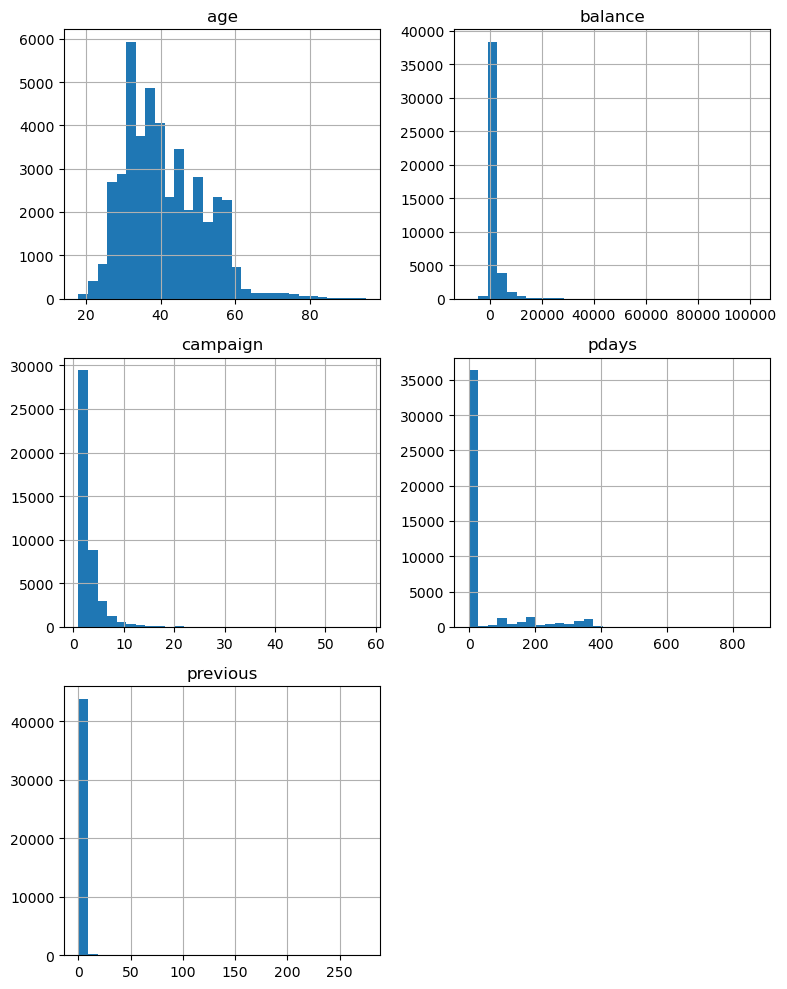

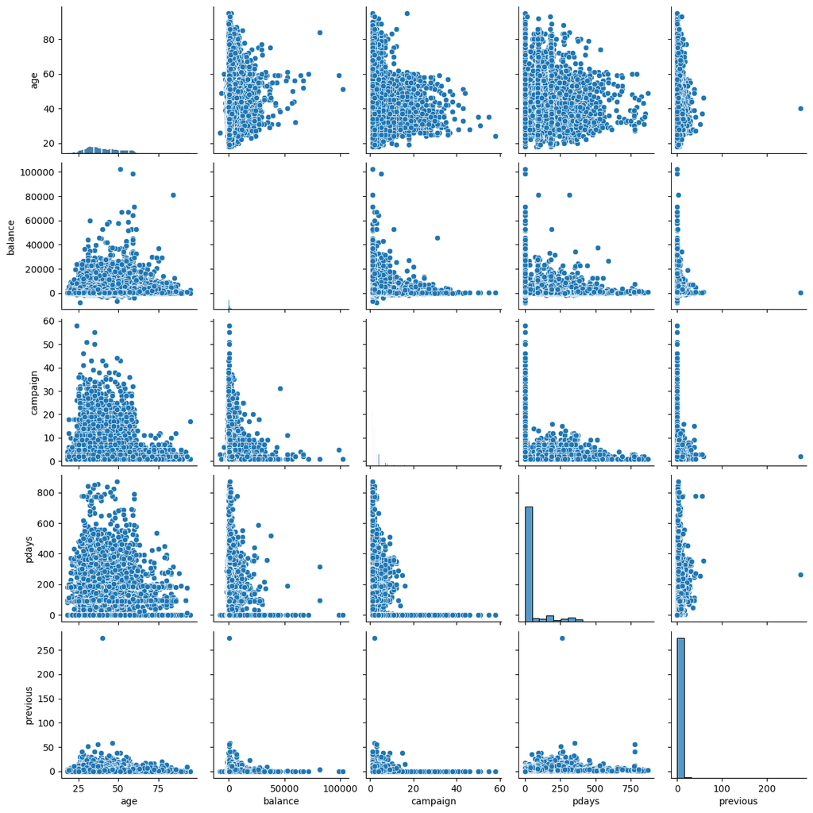

```python
X_num.hist(bins=30, figsize=(8,10))
plt.tight_layout()
plt.show()
sns.pairplot(X_num)
plt.show()
```

```python
#categoritical variables analysis
for col in X_categorical.columns:
    print(f"Value counts for column {col}:")
    print(X_categorical[col].value_counts())
    print("\n")

#This functionwas creating infinite loop --- IGNORE ---
#for col in X_categorical.columns:
    #plt.figure(figsize=(8,4))
    #sns.countplot(data=X_categorical, x=col)
    #plt.title(f'Distribution of {col}')
    #plt.show()
```

```
Value counts for column job:
job
blue-collar      9500
management       9248
technician       7438
admin.           5064
services         4060
retired          2214
self-employed    1540
entrepreneur     1459
unemployed       1276
housemaid        1211
student           920
unknown           281
Name: count, dtype: int64


Value counts for column marital:
marital
married     26632
single      12500
divorced     5079
Name: count, dtype: int64


Value counts for column education:
education
secondary    22697
tertiary     13030
primary       6668
unknown       1816
Name: count, dtype: int64


Value counts for column default:
default
no     43418
yes      793
Name: count, dtype: int64

```

[output cut: 15 more lines]

```
Value counts for column contact:
contact
cellular     28645
unknown      12722
telephone     2844
Name: count, dtype: int64


Value counts for column poutcome:
poutcome
unknown    36132
failure     4794
other       1802
success     1483
Name: count, dtype: int64
```

I'm going to first turn Y from a categorical into a factor based variable then look at correlation, also looking at the count of Success in regards to the Y category it looks like it is quite a minority only being about 3.4% of the total data may need to balance the classes later.

```python
#I'm going to first turn Y from a categorical into a factor based variable then look at correlation
encoded={'no':0,'yes':1}
hw3_training['y_encoded']=Y.map(encoded)
```

```python
corr=hw3_training.select_dtypes(include=['int64'])
corr.head()
```

|  | age | balance | day | campaign | pdays | previous | y_encoded |
| --- | --- | --- | --- | --- | --- | --- | --- |
| 0 | 58 | 2143 | 5 | 1 | -1 | 0 | 0 |
| 1 | 44 | 29 | 5 | 1 | -1 | 0 | 0 |
| 2 | 33 | 2 | 5 | 1 | -1 | 0 | 0 |
| 3 | 47 | 1506 | 5 | 1 | -1 | 0 | 0 |
| 4 | 33 | 1 | 5 | 1 | -1 | 0 | 0 |

```
                age   balance       day  campaign     pdays  previous  \
age        1.000000  0.097648 -0.008934  0.004561 -0.023299  0.001353
balance    0.097648  1.000000  0.003930 -0.016388  0.004030  0.016651
day       -0.008934  0.003930  1.000000  0.161919 -0.092109 -0.051573
campaign   0.004561 -0.016388  0.161919  1.000000 -0.088453 -0.032816
pdays     -0.023299  0.004030 -0.092109 -0.088453  1.000000  0.452952
previous   0.001353  0.016651 -0.051573 -0.032816  0.452952  1.000000
y_encoded  0.026054  0.053339 -0.029339 -0.073895  0.104913  0.093248

           y_encoded
age         0.026054
balance     0.053339
day        -0.029339
campaign   -0.073895
pdays       0.104913
previous    0.093248
y_encoded   1.000000
```

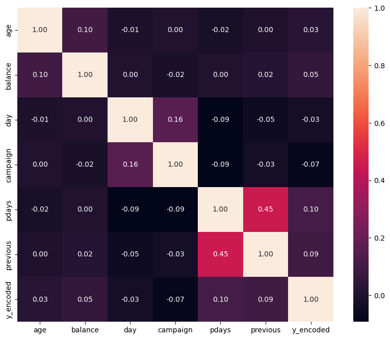

```python
corrcorr=corr.corr()
print(corrcorr)
plt.figure(figsize=(10,8))
sns.heatmap(corrcorr, annot=True, fmt=".2f")
plt.show()
#looking at the data it appears to be in relative order, now I will begin by lookinmg at correlations
```

There appears to be no strong relationships with our variable of interest Y however there appears to be a moderate relationship between pdays and previous, this makes sense since both values are inidicitve of contact with the customer previously.

2. Preprocessing.

```python
#time to look for N/A values
hw3_training.isnull().sum()
```

```
age          0
job          0
marital      0
education    0
default      0
balance      0
housing      0
loan         0
contact      0
day          0
month        0
campaign     0
pdays        0
previous     0
poutcome     0
y            0
y_encoded    0
dtype: int64
```

there is no Na's so I will move on to outliers and beginging to imputate them. Due to the high dimenstionality of the data I shall use isolation forests. but first a visualization.

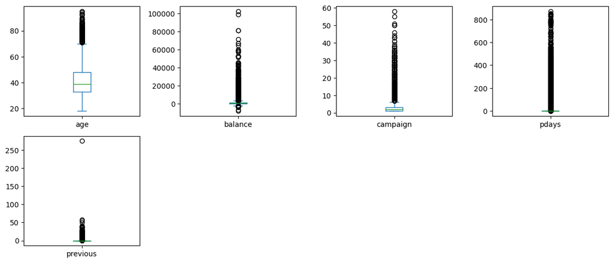

```python
#box and whisker plots to visualize outliers
X_num.plot(kind='box', subplots=True, layout=(4,4), figsize=(12,10))
plt.tight_layout()
plt.show()
```

Visually a lot of obvious outliers

```python
iso_forest=IsolationForest(contamination=0.1, random_state=42)
outliers = iso_forest.fit_predict(X.select_dtypes(include=['int64']))
mask = outliers != -1
hw3_training_cleaned = hw3_training[mask]
```

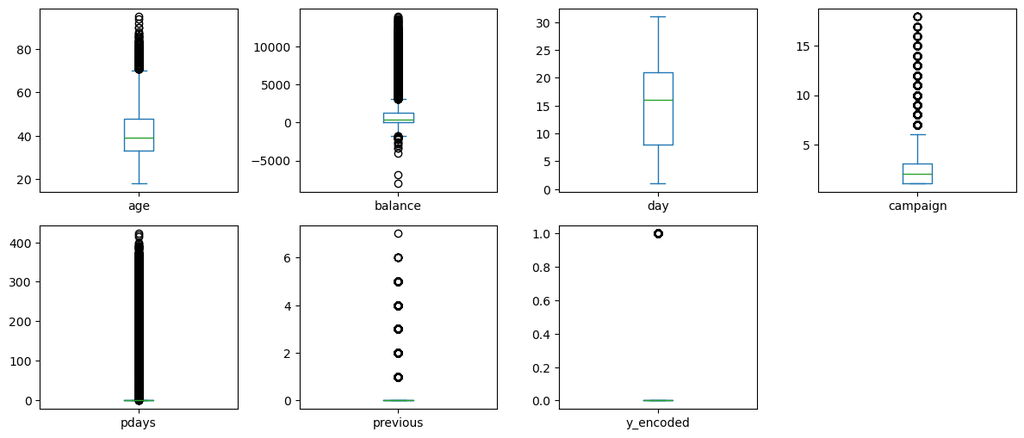

```python
#looking at the cleaned data as a box and whisker plot to see if outliers were removed
X_num_cleaned=hw3_training_cleaned.select_dtypes(include=['int64'])
X_num_cleaned.plot(kind='box', subplots=True, layout=(4,4), figsize=(12,10))
plt.tight_layout()
plt.show()
```

Many outliers were removed but because of the subject of the data such as balance or campaigns I've decided any future work would warp the data too much that the variables would no longer well represent the data

```python
#Manual encode the Month and Day categorical variables
month_mapping={'jan':1,'feb':2,'mar':3,'apr':4,'may':5,'jun':6,'jul':7,'aug':8,'sep':9,'oct':10,'nov':11,'dec':12}
hw3_training_cleaned['month']=hw3_training_cleaned['month'].map(month_mapping)
hw3_training_cleaned.head()
```

[output not shown]

|  | age | job | marital | education | default | balance | housing | loan | contact | day | month | campaign | pdays | previous | poutcome | y | y_encoded |
| --- | --- | --- | --- | --- | --- | --- | --- | --- | --- | --- | --- | --- | --- | --- | --- | --- | --- |
| 0 | 58 | management | married | tertiary | no | 2143 | yes | no | unknown | 5 | 5 | 1 | -1 | 0 | unknown | no | 0 |
| 1 | 44 | technician | single | secondary | no | 29 | yes | no | unknown | 5 | 5 | 1 | -1 | 0 | unknown | no | 0 |
| 2 | 33 | entrepreneur | married | secondary | no | 2 | yes | yes | unknown | 5 | 5 | 1 | -1 | 0 | unknown | no | 0 |
| 3 | 47 | blue-collar | married | unknown | no | 1506 | yes | no | unknown | 5 | 5 | 1 | -1 | 0 | unknown | no | 0 |
| 4 | 33 | unknown | single | unknown | no | 1 | no | no | unknown | 5 | 5 | 1 | -1 | 0 | unknown | no | 0 |

```python
#encode categorical variables
ohe = OneHotEncoder(sparse_output=False)
X_categorical_encoded = ohe.fit_transform(hw3_training_cleaned.select_dtypes(include=['object']))
X_categorical_encoded_df = pd.DataFrame(X_categorical_encoded, columns=ohe.get_feature_names_out(hw3_training_cleaned.select_dtypes(include=['object']).columns), index=hw3_training_cleaned.index)
X_categorical_encoded_df.head()
```

|  | job_admin. | job_blue-collar | job_entrepreneur | job_housemaid | job_management | job_retired | job_self-employed | job_services | job_student | job_technician | ... | loan_yes | contact_cellular | contact_telephone | contact_unknown | poutcome_failure | poutcome_other | poutcome_success | poutcome_unknown | y_no | y_yes |
| --- | --- | --- | --- | --- | --- | --- | --- | --- | --- | --- | --- | --- | --- | --- | --- | --- | --- | --- | --- | --- | --- |
| 0 | 0.0 | 0.0 | 0.0 | 0.0 | 1.0 | 0.0 | 0.0 | 0.0 | 0.0 | 0.0 | ... | 0.0 | 0.0 | 0.0 | 1.0 | 0.0 | 0.0 | 0.0 | 1.0 | 1.0 | 0.0 |
| 1 | 0.0 | 0.0 | 0.0 | 0.0 | 0.0 | 0.0 | 0.0 | 0.0 | 0.0 | 1.0 | ... | 0.0 | 0.0 | 0.0 | 1.0 | 0.0 | 0.0 | 0.0 | 1.0 | 1.0 | 0.0 |
| 2 | 0.0 | 0.0 | 1.0 | 0.0 | 0.0 | 0.0 | 0.0 | 0.0 | 0.0 | 0.0 | ... | 1.0 | 0.0 | 0.0 | 1.0 | 0.0 | 0.0 | 0.0 | 1.0 | 1.0 | 0.0 |
| 3 | 0.0 | 1.0 | 0.0 | 0.0 | 0.0 | 0.0 | 0.0 | 0.0 | 0.0 | 0.0 | ... | 0.0 | 0.0 | 0.0 | 1.0 | 0.0 | 0.0 | 0.0 | 1.0 | 1.0 | 0.0 |
| 4 | 0.0 | 0.0 | 0.0 | 0.0 | 0.0 | 0.0 | 0.0 | 0.0 | 0.0 | 0.0 | ... | 0.0 | 0.0 | 0.0 | 1.0 | 0.0 | 0.0 | 0.0 | 1.0 | 1.0 | 0.0 |

5 rows × 34 columns

```python
#combine cleaned numerical data with categorical data

hw3_training_cleaned = pd.concat([hw3_training_cleaned.select_dtypes(include=['int64']), X_categorical_encoded_df], axis=1)
hw3_training_cleaned.head()
```

|  | age | balance | day | month | campaign | pdays | previous | y_encoded | job_admin. | job_blue-collar | ... | loan_yes | contact_cellular | contact_telephone | contact_unknown | poutcome_failure | poutcome_other | poutcome_success | poutcome_unknown | y_no | y_yes |
| --- | --- | --- | --- | --- | --- | --- | --- | --- | --- | --- | --- | --- | --- | --- | --- | --- | --- | --- | --- | --- | --- |
| 0 | 58 | 2143 | 5 | 5 | 1 | -1 | 0 | 0 | 0.0 | 0.0 | ... | 0.0 | 0.0 | 0.0 | 1.0 | 0.0 | 0.0 | 0.0 | 1.0 | 1.0 | 0.0 |
| 1 | 44 | 29 | 5 | 5 | 1 | -1 | 0 | 0 | 0.0 | 0.0 | ... | 0.0 | 0.0 | 0.0 | 1.0 | 0.0 | 0.0 | 0.0 | 1.0 | 1.0 | 0.0 |
| 2 | 33 | 2 | 5 | 5 | 1 | -1 | 0 | 0 | 0.0 | 0.0 | ... | 1.0 | 0.0 | 0.0 | 1.0 | 0.0 | 0.0 | 0.0 | 1.0 | 1.0 | 0.0 |
| 3 | 47 | 1506 | 5 | 5 | 1 | -1 | 0 | 0 | 0.0 | 1.0 | ... | 0.0 | 0.0 | 0.0 | 1.0 | 0.0 | 0.0 | 0.0 | 1.0 | 1.0 | 0.0 |
| 4 | 33 | 1 | 5 | 5 | 1 | -1 | 0 | 0 | 0.0 | 0.0 | ... | 0.0 | 0.0 | 0.0 | 1.0 | 0.0 | 0.0 | 0.0 | 1.0 | 1.0 | 0.0 |

5 rows × 42 columns

```python
#drop Y columns
hw3_training_cleaned.drop(columns=['y_no','y_yes'], inplace=True)
```

This is a lot of columns but doing jobs any other way would be bad giving weights based off a title.

```python
#look at the cleaned data info
hw3_training_cleaned.describe()
```

|  | age | balance | day | month | campaign | pdays | previous | y_encoded | job_admin. | job_blue-collar | ... | housing_yes | loan_no | loan_yes | contact_cellular | contact_telephone | contact_unknown | poutcome_failure | poutcome_other | poutcome_success | poutcome_unknown |
| --- | --- | --- | --- | --- | --- | --- | --- | --- | --- | --- | --- | --- | --- | --- | --- | --- | --- | --- | --- | --- | --- |
| count | 39790.000000 | 39790.000000 | 39790.000000 | 39790.000000 | 39790.000000 | 39790.000000 | 39790.000000 | 39790.000000 | 39790.000000 | 39790.000000 | ... | 39790.000000 | 39790.000000 | 39790.000000 | 39790.000000 | 39790.000000 | 39790.000000 | 39790.000000 | 39790.000000 | 39790.000000 | 39790.000000 |
| mean | 40.587811 | 1041.503694 | 15.837095 | 6.148329 | 2.510706 | 23.453757 | 0.233049 | 0.106559 | 0.115079 | 0.218271 | ... | 0.554788 | 0.835336 | 0.164664 | 0.631214 | 0.058432 | 0.310354 | 0.074315 | 0.023775 | 0.021915 | 0.879995 |
| std | 10.120797 | 1713.354809 | 8.342580 | 2.368917 | 2.179445 | 74.532358 | 0.730316 | 0.308556 | 0.319121 | 0.413077 | ... | 0.496995 | 0.370882 | 0.370882 | 0.482482 | 0.234561 | 0.462644 | 0.262286 | 0.152349 | 0.146408 | 0.324971 |
| min | 18.000000 | -8019.000000 | 1.000000 | 1.000000 | 1.000000 | -1.000000 | 0.000000 | 0.000000 | 0.000000 | 0.000000 | ... | 0.000000 | 0.000000 | 0.000000 | 0.000000 | 0.000000 | 0.000000 | 0.000000 | 0.000000 | 0.000000 | 0.000000 |
| 25% | 33.000000 | 61.000000 | 8.000000 | 5.000000 | 1.000000 | -1.000000 | 0.000000 | 0.000000 | 0.000000 | 0.000000 | ... | 0.000000 | 1.000000 | 0.000000 | 0.000000 | 0.000000 | 0.000000 | 0.000000 | 0.000000 | 0.000000 | 1.000000 |
| 50% | 39.000000 | 410.000000 | 16.000000 | 6.000000 | 2.000000 | -1.000000 | 0.000000 | 0.000000 | 0.000000 | 0.000000 | ... | 1.000000 | 1.000000 | 0.000000 | 1.000000 | 0.000000 | 0.000000 | 0.000000 | 0.000000 | 0.000000 | 1.000000 |
| 75% | 48.000000 | 1286.000000 | 21.000000 | 8.000000 | 3.000000 | -1.000000 | 0.000000 | 0.000000 | 0.000000 | 0.000000 | ... | 1.000000 | 1.000000 | 0.000000 | 1.000000 | 0.000000 | 1.000000 | 0.000000 | 0.000000 | 0.000000 | 1.000000 |
| max | 95.000000 | 13893.000000 | 31.000000 | 12.000000 | 18.000000 | 422.000000 | 7.000000 | 1.000000 | 1.000000 | 1.000000 | ... | 1.000000 | 1.000000 | 1.000000 | 1.000000 | 1.000000 | 1.000000 | 1.000000 | 1.000000 | 1.000000 | 1.000000 |

8 rows × 40 columns

I'm also going to PCA the variables into another type of X to see if the original data or the PCA would give us the best prediction base

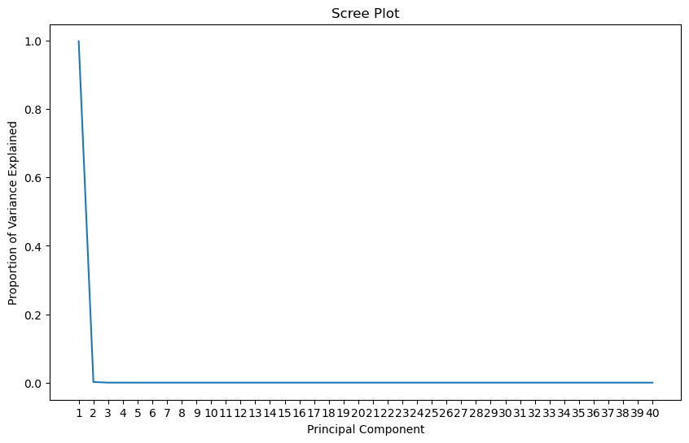

```python
from sklearn.decomposition import PCA
pca = PCA(n_components=min(hw3_training_cleaned.shape))
X_pca = pca.fit_transform(hw3_training_cleaned)
X_reduced = pca.fit_transform(hw3_training_cleaned)
X_reconstructed = pca.fit(hw3_training_cleaned).inverse_transform(X_reduced)
variance_explained = pca.explained_variance_ratio_

#Scree Plot
plt.figure(figsize=(10, 6))
plt.plot(range(1, len(variance_explained) + 1), variance_explained)
plt.xlabel('Principal Component')
plt.ylabel('Proportion of Variance Explained')
plt.title('Scree Plot')
plt.xticks(range(1, len(variance_explained) + 1))
plt.show()
```

Never mind to the PCA the variance drops at 2.

3. Model Evaluation.

```python
X_final=hw3_training_cleaned.copy().drop(columns=['y_encoded'])
Y_final=hw3_training_cleaned['y_encoded']
```

```python
#split the data into training and validation sets
X_train, X_val, Y_train, Y_val = train_test_split(X_final, Y_final, test_size=0.2, random_state=42)
#scale the data
scaler = RobustScaler()
X_train_scaled = scaler.fit_transform(X_train)
X_val_scaled = scaler.transform(X_val)
```

Im going to try a few models then try to fine tune the one with the closes F1 score

```python
#train a random forest model
rf_model = RandomForestRegressor(n_estimators=100, random_state=42)
rf_model.fit(X_train_scaled, Y_train)
Y_val_pred = rf_model.predict(X_val_scaled)

# Evaluate the model with F1 Score
Y_val_pred_binary = (Y_val_pred > 0.5).astype(int)
f1 = f1_score(Y_val, Y_val_pred_binary)
print(f"F1 Score on validation set: {f1}")
```

```
F1 Score on validation set: 0.25155004428697963
```

```python
#linear regression model
sgd_model = SGDRegressor(max_iter=1000, tol=1e-3, random_state=42)
sgd_model.fit(X_train_scaled, Y_train)
Y_val_pred_sgd = sgd_model.predict(X_val_scaled)
Y_val_pred_sgd_binary = (Y_val_pred_sgd > 0.5).astype(int)
f1_sgd = f1_score(Y_val, Y_val_pred_sgd_binary)
print(f"F1 Score for SGD model on validation set: {f1_sgd}")
```

```
F1 Score for SGD model on validation set: 0.1728848114169215
```

```python
#SGDlassifier model
from sklearn.linear_model import SGDClassifier
sgd_classifier = SGDClassifier(max_iter=1000, tol=1e-3, random_state=42)
sgd_classifier.fit(X_train_scaled, Y_train)
Y_val_pred_sgd_clf = sgd_classifier.predict(X_val_scaled)
f1_sgd_clf = f1_score(Y_val, Y_val_pred_sgd_clf)
print(f"F1 Score for SGD Classifier model on validation set: {f1_sgd_clf}")
```

```
F1 Score for SGD Classifier model on validation set: 0.020737327188940093
```

```python
#decision tree model
dt_model = DecisionTreeRegressor(random_state=42)
dt_model.fit(X_train_scaled, Y_train)
Y_val_pred_dt = dt_model.predict(X_val_scaled)
Y_val_pred_dt_binary = (Y_val_pred_dt > 0.5).astype(int)
f1_dt = f1_score(Y_val, Y_val_pred_dt_binary)
print(f"F1 Score for Decision Tree model on validation set: {f1_dt}")
```

```
F1 Score for Decision Tree model on validation set: 0.2523041474654378
```

not getting above .25 F1 score will try with a cross validation on each model

```python
#cross validation for a Decision Tree Regressor
dt_model_cv = DecisionTreeRegressor(random_state=42)
cv_results = cross_validate(dt_model_cv, X_final, Y_final, cv=5, scoring='f1', return_train_score=True)
print("Cross-validation F1 scores:", np.mean(cv_results['test_score']))
```

```
Cross-validation F1 scores: 0.16507882719218542
```

Maybe an SVM or KNN might work best if not we go to a neural network

```python
#SVM model
from sklearn.svm import SVC
svm_model = SVC(kernel='rbf', random_state=42)
svm_model.fit(X_train_scaled, Y_train)
Y_val_pred_svm = svm_model.predict(X_val_scaled)
f1_svm = f1_score(Y_val, Y_val_pred_svm)
print(f"F1 Score for SVM model on validation set: {f1_svm}")
```

```
F1 Score for SVM model on validation set: 0.0
```

```python
#KNN model
from sklearn.neighbors import KNeighborsClassifier
knn_model = KNeighborsClassifier(n_neighbors=5)
knn_model.fit(X_train_scaled, Y_train)
Y_val_pred_knn = knn_model.predict(X_val_scaled)
f1_knn = f1_score(Y_val, Y_val_pred_knn)
print(f"F1 Score for KNN model on validation set: {f1_knn}")
```

```
F1 Score for KNN model on validation set: 0.21441124780316345
```

```python
#nueral network model
from sklearn.neural_network import MLPClassifier
mlp_model = MLPClassifier(solver='lbfgs',hidden_layer_sizes=(20,10), max_iter=1000, random_state=42)
mlp_model.fit(X_train_scaled, Y_train)
Y_val_pred_mlp = mlp_model.predict(X_val_scaled)
f1_mlp = f1_score(Y_val, Y_val_pred_mlp)
print(f"F1 Score for MLP model on validation set: {f1_mlp}")
```

```
F1 Score for MLP model on validation set: 0.22648752399232247
```

[output not shown]

Due to the class imbalances I shall SMOTE that Data then reattempt some models before changing the hyperparameters.

```python
#smote the data
from imblearn.over_sampling import RandomOverSampler, SMOTE
from imblearn.under_sampling import RandomUnderSampler
smote = SMOTE(random_state=42)
X_resampled, Y_resampled = smote.fit_resample(X_final, Y_final)
```

```python
#random forest after smote
X_train_res, X_val_res, Y_train_res, Y_val_res = train_test_split(X_resampled, Y_resampled,test_size=0.2, random_state=42)
X_train_res=X_train_res.drop(columns=['day','month',])
X_val_res=X_val_res.drop(columns=['day','month',])
scaler_res = RobustScaler()
X_train_res_scaled = scaler_res.fit_transform(X_train_res)
X_val_res_scaled = scaler_res.transform(X_val_res)
rf_model_res = RandomForestRegressor(n_estimators=100, random_state=42)
rf_model_res.fit(X_train_res_scaled, Y_train_res)
rf_model_res.fit(X_train_res_scaled, Y_train_res)
Y_val_pred_res = rf_model_res.predict(X_val_res_scaled)
Y_val_pred_res_binary = (Y_val_pred_res > 0.5).astype(int)
f1_res = f1_score(Y_val_res, Y_val_pred_res_binary)
print(f"F1 Score on validation set after SMOTE: {f1_res}")
```

```
F1 Score on validation set after SMOTE: 0.9322244108849493
```

Yeah got a High F1 score not to apply to the test data

4. Test Data

```python
#apply to test data
X_test= hw3_testing.drop(columns=['day','month',])
X_test_num=X_test.select_dtypes(include=['int64','float64'])
X_test_categorical=X_test.select_dtypes(include=['object'])
#fit the data then transform it
X_test_categorical_encoded = ohe.fit_transform(X_test_categorical)
X_test_categorical_encoded_df = pd.DataFrame(X_test_categorical_encoded, columns=ohe.get_feature_names_out(X_test_categorical.columns), index=X_test.index)
X_test_final = pd.concat([X_test_num, X_test_categorical_encoded_df], axis=1)
X_test_final_scaled = scaler_res.fit_transform(X_test_final)
```

```python
#predict on test data
Y_test_pred = rf_model_res.predict(X_test_final_scaled)
#turn back to yes or no for results
yes_no_mapping={0:'no',1:'yes'}
Y_test_pred = [yes_no_mapping[int(pred)] for pred in Y_test_pred]
print(Y_test_pred)
```

[output not shown]

```python
#save to CSV
answer = 'answer_final.csv'
np.savetxt(answer, Y_test_pred, fmt='%s')
print("Predictions saved to answer.csv")
```

```
Predictions saved to answer.csv
```